# Módulo 6

# PROYECTO 1

# Redes Neuronales Recurrentes

## Gretel Fernanda Trejo Hernandez

```python
from tensorflow.keras.models import Sequential
from tensorflow.keras.layers import LSTM, Dense
```

La base de datos *F1 Races Results dataset 1950 to 2024* ofrece un registro completo de los ganadores de las carreras de Fórmula 1 desde la temporada inaugural de 1950 hasta los datos más recientes de 2024. Detalla a los pilotos ganadores, sus respectivos equipos, los circuitos donde lograron la victoria, además de otros detalles.

Link: https://www.kaggle.com/datasets/lakshayjain611/f1-races-results-dataset-1950-to-2024/data?select=winners.csv

Se creará un modelo LSTM (Long Short-Term Memory es una Red Neuronal Recurrente) para explorar la narrativa de la F1 desde su año inaugural. Este tipo de modelo es adecuado para este dataset debido a la naturaleza temporal de los datos y lo excelentes que son los LSTM para predecir o generar datos de series temporales. Los datos de F1 tiene una relación temporal, ya que el rendimiento de los pilotos en una temporada puede depender de su rendimiento en temporadas anteriores. Su objetivo es predecir el número de vueltas en función de características históricas de las carreras como el tiempo de la carrera, el tipo de circuito, y las variables de la temporada.

En el código se ha utilizado el optimizador *Adam* el cual ajusta automáticamente las tasas de apendizaje durante el entremaniemto y es muy eficaz para la convergencia en modelos con grandes cantidades de datos y parámetros, lo cual es útil en este caso, pues se entrena un modelo con secuencias temporales de largo plazo. Además de ser un optimizador rápido en la práctica lo que facilita el manejo de grandes volúmenes de datos.

```python
import numpy as np
import pandas as pd
from sklearn.preprocessing import MinMaxScaler
from sklearn.impute import SimpleImputer
from sklearn.metrics import r2_score
from tensorflow.keras.models import Sequential
from tensorflow.keras.layers import LSTM, Dense, Dropout
from tensorflow.keras.optimizers import Adam
import matplotlib.pyplot as plt

winners = pd.read_csv('DCD-Modulo-6/winners.csv')
print(winners.head())
print(winners.info())
```

```
         Grand Prix        Date                Winner  \
0     Great Britain  1950-05-13         Nino  Farina
1            Monaco  1950-05-21  Juan Manuel  Fangio
2  Indianapolis 500  1950-05-30      Johnnie Parsons
3       Switzerland  1950-06-04         Nino  Farina
4           Belgium  1950-06-18  Juan Manuel  Fangio

                        Car   Laps         Time Name Code
0                Alfa Romeo   70.0  2:13:23.600       FAR
1                Alfa Romeo  100.0  3:13:18.700       FAN
2  Kurtis Kraft Offenhauser  138.0  2:46:55.970       PAR
3                Alfa Romeo   42.0  2:02:53.700       FAR
4                Alfa Romeo   35.0  2:47:26.000       FAN
<class 'pandas.core.frame.DataFrame'>
RangeIndex: 1110 entries, 0 to 1109
Data columns (total 7 columns):
 #   Column      Non-Null Count  Dtype
---  ------      --------------  -----
 0   Grand Prix  1110 non-null   object
 1   Date        1110 non-null   object
 2   Winner      1110 non-null   object
 3   Car         1110 non-null   object
 4   Laps        1107 non-null   float64
 5   Time        1107 non-null   object
 6   Name Code   1110 non-null   object
dtypes: float64(1), object(6)
memory usage: 60.8+ KB
None
```

```python
from sklearn.preprocessing import LabelEncoder, StandardScaler
from tensorflow.keras.layers import Embedding, Concatenate, Input, Flatten, Reshape
from tensorflow.keras.models import Model

#Las varibles de interes son Laps, Time seconds, Average Lap Time, Grand Prix y Year, Date se usará como index
# Ya que Date y Time son object, las convetiré a Dtype numérico

# Para Date
winners['Date'] = pd.to_datetime(winners['Date']) #Convertir a datatime

winners['Year'] = winners['Date'].dt.year #Extraer el año
winners['Month'] = winners['Date'].dt.month #Extraer el mes
winners['Day'] = winners['Date'].dt.day #Extraer el día

#Para Time
winners['Time'] = winners['Time'].astype(str) #Convertir a cadena
winners['Time'] = pd.to_timedelta(winners['Time'], errors='coerce') #Convertir a timedelta
winners['Time_seconds'] = winners['Time'].dt.total_seconds() #Convertir el total de seg a numérico

#Otra variante relevante que no aparece en el dataset es el tiempo por vuelta, se agregará como variable adicional
winners['Average_Lap_Time'] = winners['Time_seconds'] / winners['Laps']

#También es relavante el GP, ya que influye en el Lap time
 # Para usarlo como variable ursaré Embedding
label_encoder = LabelEncoder()
winners['Grand Prix_encoded'] = label_encoder.fit_transform(winners['Grand Prix'])

winners.to_csv('DCD-Modulo-6/winners_modified.csv', index=False)

print(winners.head())
print(winners.info())
```

```
         Grand Prix       Date                Winner  \
0     Great Britain 1950-05-13         Nino  Farina
1            Monaco 1950-05-21  Juan Manuel  Fangio
2  Indianapolis 500 1950-05-30      Johnnie Parsons
3       Switzerland 1950-06-04         Nino  Farina
4           Belgium 1950-06-18  Juan Manuel  Fangio

                        Car   Laps                   Time Name Code  Year  \
0                Alfa Romeo   70.0 0 days 02:13:23.600000       FAR  1950
1                Alfa Romeo  100.0 0 days 03:13:18.700000       FAN  1950
2  Kurtis Kraft Offenhauser  138.0 0 days 02:46:55.970000       PAR  1950
3                Alfa Romeo   42.0 0 days 02:02:53.700000       FAR  1950
4                Alfa Romeo   35.0        0 days 02:47:26       FAN  1950

   Month  Day  Time_seconds  Average_Lap_Time  Grand Prix_encoded
0      5   13       8003.60        114.337143                  19
1      5   21      11598.70        115.987000                  30
2      5   30      10015.97         72.579493                  22
3      6    4       7373.70        175.564286                  47
4      6   18      10046.00        287.028571                   7
<class 'pandas.core.frame.DataFrame'>
RangeIndex: 1110 entries, 0 to 1109
Data columns (total 13 columns):
 #   Column              Non-Null Count  Dtype
---  ------              --------------  -----
 0   Grand Prix          1110 non-null   object
 1   Date                1110 non-null   datetime64[ns]
 2   Winner              1110 non-null   object
 3   Car                 1110 non-null   object
 4   Laps                1107 non-null   float64
 5   Time                1103 non-null   timedelta64[ns]
 6   Name Code           1110 non-null   object
 7   Year                1110 non-null   int32
 8   Month               1110 non-null   int32
 9   Day                 1110 non-null   int32
 10  Time_seconds        1103 non-null   float64
 11  Average_Lap_Time    1103 non-null   float64
 12  Grand Prix_encoded  1110 non-null   int32
dtypes: datetime64[ns](1), float64(3), int32(4), object(4), timedelta64[ns](1)
memory usage: 95.5+ KB
None
```

```python
#Cargar los datos de entrenamiento
train_data = pd.read_csv('DCD-Modulo-6/winners_modified.csv', index_col='Date', parse_dates=True)

#Debido a que los datos de cada uno de los GP son específicos, para entrenar y validar el modelo dividiré mi base en 2
train_data_train = train_data[train_data['Year'] < 2010]  # Datos hasta 2010 para entrenamiento
train_data_val = train_data[train_data['Year'] >= 2010]  # Datos de 2010 para validación

 #Normalizaré las variables a usar, esto mejorará el rendimiento y estabilidad de el modelo
   #Para entrenaminento
scaler = StandardScaler()
train_data_train[['Laps', 'Time_seconds', 'Average_Lap_Time', 'Year']] = scaler.fit_transform(train_data_train[['Laps', 'Time_seconds', 'Average_Lap_Time', 'Year']])
   #Para validación
train_data_val[['Laps', 'Time_seconds', 'Average_Lap_Time', 'Year']] = scaler.transform(
    train_data_val[['Laps', 'Time_seconds', 'Average_Lap_Time', 'Year']]
)

# Crear las entradas para el modelo
input_grand_prix = Input(shape=(1,), dtype='int32', name='Grand_Prix_Input')  # Para Grand Prix
input_laps = Input(shape=(1,), dtype='float32', name='Laps_Input')  # Para Laps
input_time_seconds = Input(shape=(1,), dtype='float32', name='Time_Seconds_Input')  # Para Time_seconds
input_average_lap_time = Input(shape=(1,), dtype='float32', name='Average_Lap_Time_Input')  # Para Average_Lap_Time
input_year = Input(shape=(1,), dtype='float32', name='Year_Input')  # Para Year

# Capa de Embeddings para 'Grand Prix'
embedding_dim = 8  # Tamaño del espacio de embeddings
max_grand_prix = len(label_encoder.classes_)  # Número total de categorías únicas de 'Grand Prix'
embedding_layer = Embedding(input_dim=max_grand_prix, output_dim=embedding_dim, input_length=1)(input_grand_prix)

# Usar Flatten para aplanar la salida de la capa de embeddings
embedding_layer = Flatten()(embedding_layer)

# Concatenar la capa de embeddings con las otras variables
concatenated = Concatenate()([embedding_layer, input_laps, input_time_seconds, input_average_lap_time, input_year])

# Asegúrate de que la entrada a LSTM tenga 3 dimensiones
reshaped = Reshape((1, concatenated.shape[1]))(concatenated)

# LSTM y capa densa
lstm_layer = LSTM(64)(reshaped)
output = Dense(1, activation='linear')(lstm_layer)

# Crear el modelo
model = Model(inputs=[input_grand_prix, input_laps, input_time_seconds, input_average_lap_time, input_year], outputs=output)

# Compilar el modelo
model.compile(optimizer=Adam(), loss='mse')

# Resumen del modelo
model.summary()

train_data_train_or = train_data_train[['Laps', 'Time_seconds', 'Average_Lap_Time', 'Grand Prix_encoded', 'Year']]

#Limpieza de datos
train_data_train_or.replace(['---', '---', 'NaN', '', ''], np.nan, inplace=True)
imputer = SimpleImputer(strategy = 'mean')
train_data_train_or = pd.DataFrame(imputer.fit_transform(train_data_train_or), columns = train_data_train_or.columns, index=train_data_train_or.index)

#Escalado de datos
scaler = MinMaxScaler(feature_range=(0,1)) #Transforma los datos en 0 y 1
train_scaled_train = scaler.fit_transform(train_data_train_or)

#Crear secuencias temporales de datos para el entrenamiento
def create_dataset(dataset, look_back=60):
  X, Y = [], []
  for i in range(len(dataset) - look_back):
    a = dataset[i:(i+look_back), :]
    X.append(a)
    Y.append(dataset[i+look_back, 0])
  return np.array(X), np.array(Y)

X_train, y_train = create_dataset(train_scaled_train, 60)

#Modelo LSMT
model = Sequential([
    LSTM(100, input_shape=(X_train.shape[1], X_train.shape[2]), return_sequences=True), #return_sequences=True Devuelve salidas para cada paso (necesario para apilar LSTM)
    Dropout(0.2), #Evita el sobreajuste, apaga aleatoriamente el 20% de las neuronas durante el entrenamiento
    LSTM(100, return_sequences=False), #return sequences=False, nos da la salida final y no toda la sequencia
    Dense(1) #capa final densa
])

model.compile(optimizer=Adam(learning_rate=0.01), loss='mean_squared_error')
```

```
Model: "functional"
```

```
┏━━━━━━━━━━━━━━━━━━━━━━━━━━━━━━━┳━━━━━━━━━━━━━━━━━━━━━━━━━━━┳━━━━━━━━━━━━━━━━━┳━━━━━━━━━━━━━━━━━━━━━━━━━━━━┓
┃ Layer (type)                  ┃ Output Shape              ┃         Param # ┃ Connected to               ┃
┡━━━━━━━━━━━━━━━━━━━━━━━━━━━━━━━╇━━━━━━━━━━━━━━━━━━━━━━━━━━━╇━━━━━━━━━━━━━━━━━╇━━━━━━━━━━━━━━━━━━━━━━━━━━━━┩
│ Grand_Prix_Input (InputLayer) │ (None, 1)                 │               0 │ -                          │
├───────────────────────────────┼───────────────────────────┼─────────────────┼────────────────────────────┤
│ embedding (Embedding)         │ (None, 1, 8)              │             424 │ Grand_Prix_Input[0][0]     │
├───────────────────────────────┼───────────────────────────┼─────────────────┼────────────────────────────┤
│ flatten (Flatten)             │ (None, 8)                 │               0 │ embedding[0][0]            │
├───────────────────────────────┼───────────────────────────┼─────────────────┼────────────────────────────┤
│ Laps_Input (InputLayer)       │ (None, 1)                 │               0 │ -                          │
├───────────────────────────────┼───────────────────────────┼─────────────────┼────────────────────────────┤
│ Time_Seconds_Input            │ (None, 1)                 │               0 │ -                          │
│ (InputLayer)                  │                           │                 │                            │
├───────────────────────────────┼───────────────────────────┼─────────────────┼────────────────────────────┤
│ Average_Lap_Time_Input        │ (None, 1)                 │               0 │ -                          │
│ (InputLayer)                  │                           │                 │                            │
├───────────────────────────────┼───────────────────────────┼─────────────────┼────────────────────────────┤
│ Year_Input (InputLayer)       │ (None, 1)                 │               0 │ -                          │
├───────────────────────────────┼───────────────────────────┼─────────────────┼────────────────────────────┤
│ concatenate (Concatenate)     │ (None, 12)                │               0 │ flatten[0][0],             │
│                               │                           │                 │ Laps_Input[0][0],          │
│                               │                           │                 │ Time_Seconds_Input[0][0],  │
│                               │                           │                 │ Average_Lap_Time_Input[0]… │
│                               │                           │                 │ Year_Input[0][0]           │
├───────────────────────────────┼───────────────────────────┼─────────────────┼────────────────────────────┤
│ reshape (Reshape)             │ (None, 1, 12)             │               0 │ concatenate[0][0]          │
├───────────────────────────────┼───────────────────────────┼─────────────────┼────────────────────────────┤
│ lstm (LSTM)                   │ (None, 64)                │          19,712 │ reshape[0][0]              │
├───────────────────────────────┼───────────────────────────┼─────────────────┼────────────────────────────┤
│ dense (Dense)                 │ (None, 1)                 │              65 │ lstm[0][0]                 │
└───────────────────────────────┴───────────────────────────┴─────────────────┴────────────────────────────┘
```

```
 Total params: 20,201 (78.91 KB)
```

```
 Trainable params: 20,201 (78.91 KB)
```

```
 Non-trainable params: 0 (0.00 B)
```

```python
model.summary()
```

```
Model: "sequential"
```

```
┏━━━━━━━━━━━━━━━━━━━━━━━━━━━━━━━━━━━━━━┳━━━━━━━━━━━━━━━━━━━━━━━━━━━━━┳━━━━━━━━━━━━━━━━━┓
┃ Layer (type)                         ┃ Output Shape                ┃         Param # ┃
┡━━━━━━━━━━━━━━━━━━━━━━━━━━━━━━━━━━━━━━╇━━━━━━━━━━━━━━━━━━━━━━━━━━━━━╇━━━━━━━━━━━━━━━━━┩
│ lstm_1 (LSTM)                        │ (None, 60, 100)             │          42,400 │
├──────────────────────────────────────┼─────────────────────────────┼─────────────────┤
│ dropout (Dropout)                    │ (None, 60, 100)             │               0 │
├──────────────────────────────────────┼─────────────────────────────┼─────────────────┤
│ lstm_2 (LSTM)                        │ (None, 100)                 │          80,400 │
├──────────────────────────────────────┼─────────────────────────────┼─────────────────┤
│ dense_1 (Dense)                      │ (None, 1)                   │             101 │
└──────────────────────────────────────┴─────────────────────────────┴─────────────────┘
```

```
 Total params: 122,901 (480.08 KB)
```

```
 Trainable params: 122,901 (480.08 KB)
```

```
 Non-trainable params: 0 (0.00 B)
```

```python
#Para observar la correlación entre las variables
train_data_mod_col = train_data[['Laps', 'Time_seconds', 'Average_Lap_Time', 'Grand Prix_encoded', 'Year']]

correlaciones = train_data_mod_col.corr()
print(correlaciones)
```

```
                        Laps  Time_seconds  Average_Lap_Time  \
Laps                1.000000      0.465542         -0.494597
Time_seconds        0.465542      1.000000          0.364643
Average_Lap_Time   -0.494597      0.364643          1.000000
Grand Prix_encoded  0.193647      0.086547         -0.097504
Year               -0.238666     -0.593459         -0.290533

                    Grand Prix_encoded      Year
Laps                          0.193647 -0.238666
Time_seconds                  0.086547 -0.593459
Average_Lap_Time             -0.097504 -0.290533
Grand Prix_encoded            1.000000 -0.073391
Year                         -0.073391  1.000000
```

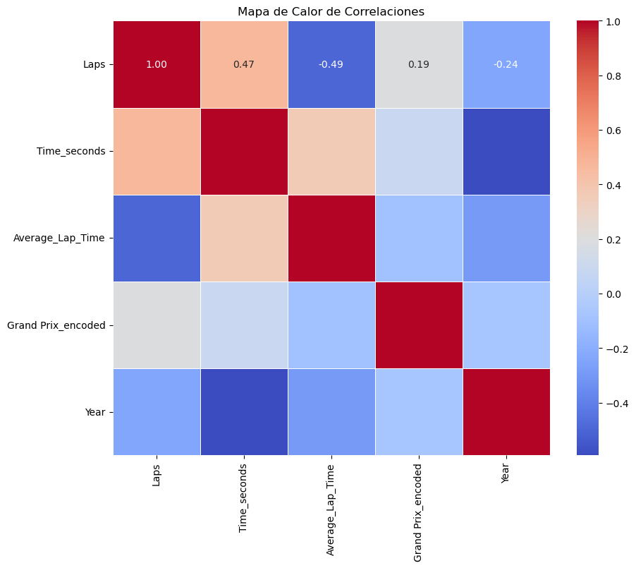

```python
import seaborn as sns

# Mostrando el heatmap
plt.figure(figsize=(10, 8))
sns.heatmap(correlaciones, annot=True, cmap='coolwarm', fmt='.2f', linewidths=0.5)
plt.title('Mapa de Calor de Correlaciones')
plt.show()
```

```python
#Entrenar el modelo
model.fit(X_train, y_train, epochs=50, batch_size=32, verbose=1)
```

```
24/24 ━━━━━━━━━━━━━━━━━━━━ 5s 60ms/step - loss: 0.3865
24/24 ━━━━━━━━━━━━━━━━━━━━ 1s 59ms/step - loss: 0.0117
24/24 ━━━━━━━━━━━━━━━━━━━━ 1s 59ms/step - loss: 0.0076
24/24 ━━━━━━━━━━━━━━━━━━━━ 2s 67ms/step - loss: 0.0092
24/24 ━━━━━━━━━━━━━━━━━━━━ 2s 65ms/step - loss: 0.0087
24/24 ━━━━━━━━━━━━━━━━━━━━ 1s 60ms/step - loss: 0.0102
24/24 ━━━━━━━━━━━━━━━━━━━━ 1s 59ms/step - loss: 0.0093
24/24 ━━━━━━━━━━━━━━━━━━━━ 2s 64ms/step - loss: 0.0085
24/24 ━━━━━━━━━━━━━━━━━━━━ 1s 58ms/step - loss: 0.0100
24/24 ━━━━━━━━━━━━━━━━━━━━ 1s 60ms/step - loss: 0.0092
24/24 ━━━━━━━━━━━━━━━━━━━━ 2s 67ms/step - loss: 0.0091
24/24 ━━━━━━━━━━━━━━━━━━━━ 2s 69ms/step - loss: 0.0086
24/24 ━━━━━━━━━━━━━━━━━━━━ 1s 60ms/step - loss: 0.0081
24/24 ━━━━━━━━━━━━━━━━━━━━ 1s 59ms/step - loss: 0.0079
24/24 ━━━━━━━━━━━━━━━━━━━━ 2s 70ms/step - loss: 0.0092
24/24 ━━━━━━━━━━━━━━━━━━━━ 2s 62ms/step - loss: 0.0088
24/24 ━━━━━━━━━━━━━━━━━━━━ 2s 69ms/step - loss: 0.0096
24/24 ━━━━━━━━━━━━━━━━━━━━ 2s 64ms/step - loss: 0.0090
24/24 ━━━━━━━━━━━━━━━━━━━━ 1s 60ms/step - loss: 0.0100
24/24 ━━━━━━━━━━━━━━━━━━━━ 1s 59ms/step - loss: 0.0084
24/24 ━━━━━━━━━━━━━━━━━━━━ 1s 61ms/step - loss: 0.0093
24/24 ━━━━━━━━━━━━━━━━━━━━ 2s 65ms/step - loss: 0.0093
24/24 ━━━━━━━━━━━━━━━━━━━━ 2s 68ms/step - loss: 0.0079
24/24 ━━━━━━━━━━━━━━━━━━━━ 2s 64ms/step - loss: 0.0099
24/24 ━━━━━━━━━━━━━━━━━━━━ 2s 63ms/step - loss: 0.0081
24/24 ━━━━━━━━━━━━━━━━━━━━ 2s 65ms/step - loss: 0.0075
24/24 ━━━━━━━━━━━━━━━━━━━━ 2s 69ms/step - loss: 0.0082
24/24 ━━━━━━━━━━━━━━━━━━━━ 2s 69ms/step - loss: 0.0083
24/24 ━━━━━━━━━━━━━━━━━━━━ 2s 70ms/step - loss: 0.0089
24/24 ━━━━━━━━━━━━━━━━━━━━ 2s 64ms/step - loss: 0.0092
24/24 ━━━━━━━━━━━━━━━━━━━━ 1s 61ms/step - loss: 0.0078
24/24 ━━━━━━━━━━━━━━━━━━━━ 1s 60ms/step - loss: 0.0075
24/24 ━━━━━━━━━━━━━━━━━━━━ 1s 61ms/step - loss: 0.0077
24/24 ━━━━━━━━━━━━━━━━━━━━ 2s 64ms/step - loss: 0.0079
24/24 ━━━━━━━━━━━━━━━━━━━━ 1s 61ms/step - loss: 0.0084
24/24 ━━━━━━━━━━━━━━━━━━━━ 1s 60ms/step - loss: 0.0085
24/24 ━━━━━━━━━━━━━━━━━━━━ 2s 62ms/step - loss: 0.0081
24/24 ━━━━━━━━━━━━━━━━━━━━ 2s 64ms/step - loss: 0.0077
24/24 ━━━━━━━━━━━━━━━━━━━━ 2s 67ms/step - loss: 0.0088
24/24 ━━━━━━━━━━━━━━━━━━━━ 2s 64ms/step - loss: 0.0074
24/24 ━━━━━━━━━━━━━━━━━━━━ 2s 61ms/step - loss: 0.0070
24/24 ━━━━━━━━━━━━━━━━━━━━ 1s 60ms/step - loss: 0.0085
24/24 ━━━━━━━━━━━━━━━━━━━━ 2s 63ms/step - loss: 0.0071
24/24 ━━━━━━━━━━━━━━━━━━━━ 2s 63ms/step - loss: 0.0091
24/24 ━━━━━━━━━━━━━━━━━━━━ 1s 60ms/step - loss: 0.0075
24/24 ━━━━━━━━━━━━━━━━━━━━ 1s 60ms/step - loss: 0.0071
24/24 ━━━━━━━━━━━━━━━━━━━━ 1s 60ms/step - loss: 0.0077
24/24 ━━━━━━━━━━━━━━━━━━━━ 2s 69ms/step - loss: 0.0084
24/24 ━━━━━━━━━━━━━━━━━━━━ 2s 63ms/step - loss: 0.0071
24/24 ━━━━━━━━━━━━━━━━━━━━ 2s 61ms/step - loss: 0.0062
```

```
<keras.src.callbacks.history.History at 0x2cae35cf740>
```

```python
#Prepararlos datos reales del 2010 para comparación
train_data_val_or = train_data_val[['Laps', 'Time_seconds', 'Average_Lap_Time', 'Grand Prix_encoded', 'Year']]
train_data_val_or.replace(['---', '---', 'NaN', '', ''], np.nan, inplace=True)
train_data_val_or = pd.DataFrame(imputer.transform(train_data_val_or), columns=train_data_val_or.columns, index=train_data_val_or.index)
train_scaled_val_or = scaler.transform(train_data_val_or)
```

```
9/9 ━━━━━━━━━━━━━━━━━━━━ 1s 65ms/step
```

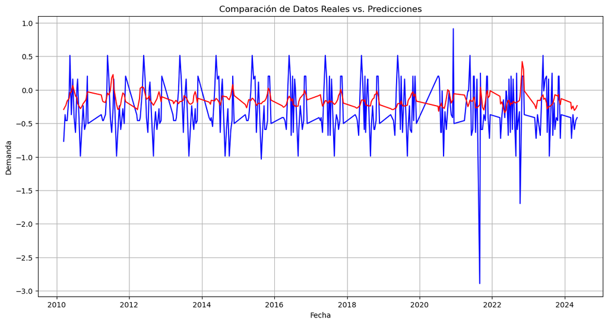

```python
#Crear datos de entrada para predicción
X_real, _ = create_dataset(np.vstack([train_scaled_train[-60:], train_scaled_val_or]), 60)

#Predicciones
predictions_scaled = model.predict(X_real)
predictions_scaled = predictions_scaled.reshape(-1, 1) # Aseguranos de que las predicciones tengan 2 dimensiones
predictions_with_zeros = np.concatenate([predictions_scaled, np.zeros((predictions_scaled.shape[0], 4))], axis=1) #Crea una matriz de 0's del tamaño del dataset original
predictions = scaler.inverse_transform(predictions_with_zeros) #Aplicando la inversa del escalado
predictions = predictions[:, 0] #Extrae la columna de predicciones

#Datos reales para comparar
real_demand = scaler.inverse_transform(train_scaled_val_or)[:, 0]

#Graficar
plt.figure(figsize=(14, 7))
plt.plot(train_data_val_or.index, real_demand, label='Datos Reales 2024', color='blue')
plt.plot(train_data_val_or.index[:len(predictions)], predictions, label='Predicciones 2024', color='red')
plt.title('Comparación de Datos Reales vs. Predicciones')
plt.xlabel('Fecha')
plt.ylabel('Demanda')
plt.grid(True)
plt.show()
```

Para observar si se tiene una mejor predicción, esta se observará a partir del 2000

```
Model: "functional_4"
```

```
┏━━━━━━━━━━━━━━━━━━━━━━━━━━━━━━━┳━━━━━━━━━━━━━━━━━━━━━━━━━━━┳━━━━━━━━━━━━━━━━━┳━━━━━━━━━━━━━━━━━━━━━━━━━━━━┓
┃ Layer (type)                  ┃ Output Shape              ┃         Param # ┃ Connected to               ┃
┡━━━━━━━━━━━━━━━━━━━━━━━━━━━━━━━╇━━━━━━━━━━━━━━━━━━━━━━━━━━━╇━━━━━━━━━━━━━━━━━╇━━━━━━━━━━━━━━━━━━━━━━━━━━━━┩
│ Grand_Prix_Input (InputLayer) │ (None, 1)                 │               0 │ -                          │
├───────────────────────────────┼───────────────────────────┼─────────────────┼────────────────────────────┤
│ embedding_2 (Embedding)       │ (None, 1, 8)              │             424 │ Grand_Prix_Input[0][0]     │
├───────────────────────────────┼───────────────────────────┼─────────────────┼────────────────────────────┤
│ flatten_2 (Flatten)           │ (None, 8)                 │               0 │ embedding_2[0][0]          │
├───────────────────────────────┼───────────────────────────┼─────────────────┼────────────────────────────┤
│ Laps_Input (InputLayer)       │ (None, 1)                 │               0 │ -                          │
├───────────────────────────────┼───────────────────────────┼─────────────────┼────────────────────────────┤
│ Time_Seconds_Input            │ (None, 1)                 │               0 │ -                          │
│ (InputLayer)                  │                           │                 │                            │
├───────────────────────────────┼───────────────────────────┼─────────────────┼────────────────────────────┤
│ Average_Lap_Time_Input        │ (None, 1)                 │               0 │ -                          │
│ (InputLayer)                  │                           │                 │                            │
├───────────────────────────────┼───────────────────────────┼─────────────────┼────────────────────────────┤
│ Year_Input (InputLayer)       │ (None, 1)                 │               0 │ -                          │
├───────────────────────────────┼───────────────────────────┼─────────────────┼────────────────────────────┤
│ concatenate_2 (Concatenate)   │ (None, 12)                │               0 │ flatten_2[0][0],           │
│                               │                           │                 │ Laps_Input[0][0],          │
│                               │                           │                 │ Time_Seconds_Input[0][0],  │
│                               │                           │                 │ Average_Lap_Time_Input[0]… │
│                               │                           │                 │ Year_Input[0][0]           │
├───────────────────────────────┼───────────────────────────┼─────────────────┼────────────────────────────┤
│ reshape_2 (Reshape)           │ (None, 1, 12)             │               0 │ concatenate_2[0][0]        │
├───────────────────────────────┼───────────────────────────┼─────────────────┼────────────────────────────┤
│ lstm_6 (LSTM)                 │ (None, 64)                │          19,712 │ reshape_2[0][0]            │
├───────────────────────────────┼───────────────────────────┼─────────────────┼────────────────────────────┤
│ dense_4 (Dense)               │ (None, 1)                 │              65 │ lstm_6[0][0]               │
└───────────────────────────────┴───────────────────────────┴─────────────────┴────────────────────────────┘
```

```
 Total params: 20,201 (78.91 KB)
```

```
 Trainable params: 20,201 (78.91 KB)
```

```
 Non-trainable params: 0 (0.00 B)
```

```
19/19 ━━━━━━━━━━━━━━━━━━━━ 5s 62ms/step - loss: 1.4196
19/19 ━━━━━━━━━━━━━━━━━━━━ 1s 61ms/step - loss: 0.0168
19/19 ━━━━━━━━━━━━━━━━━━━━ 1s 56ms/step - loss: 0.0139
19/19 ━━━━━━━━━━━━━━━━━━━━ 1s 61ms/step - loss: 0.0121
19/19 ━━━━━━━━━━━━━━━━━━━━ 1s 60ms/step - loss: 0.0133
19/19 ━━━━━━━━━━━━━━━━━━━━ 1s 64ms/step - loss: 0.0113
19/19 ━━━━━━━━━━━━━━━━━━━━ 1s 64ms/step - loss: 0.0123
19/19 ━━━━━━━━━━━━━━━━━━━━ 1s 68ms/step - loss: 0.0134
19/19 ━━━━━━━━━━━━━━━━━━━━ 1s 73ms/step - loss: 0.0104
19/19 ━━━━━━━━━━━━━━━━━━━━ 1s 66ms/step - loss: 0.0127
19/19 ━━━━━━━━━━━━━━━━━━━━ 1s 59ms/step - loss: 0.0123
19/19 ━━━━━━━━━━━━━━━━━━━━ 1s 64ms/step - loss: 0.0103
19/19 ━━━━━━━━━━━━━━━━━━━━ 1s 68ms/step - loss: 0.0096
19/19 ━━━━━━━━━━━━━━━━━━━━ 1s 65ms/step - loss: 0.0113
19/19 ━━━━━━━━━━━━━━━━━━━━ 1s 62ms/step - loss: 0.0107
19/19 ━━━━━━━━━━━━━━━━━━━━ 1s 63ms/step - loss: 0.0109
19/19 ━━━━━━━━━━━━━━━━━━━━ 1s 60ms/step - loss: 0.0099
19/19 ━━━━━━━━━━━━━━━━━━━━ 1s 64ms/step - loss: 0.0098
19/19 ━━━━━━━━━━━━━━━━━━━━ 1s 62ms/step - loss: 0.0108
19/19 ━━━━━━━━━━━━━━━━━━━━ 1s 61ms/step - loss: 0.0120
19/19 ━━━━━━━━━━━━━━━━━━━━ 1s 59ms/step - loss: 0.0103
19/19 ━━━━━━━━━━━━━━━━━━━━ 1s 61ms/step - loss: 0.0114
19/19 ━━━━━━━━━━━━━━━━━━━━ 1s 63ms/step - loss: 0.0091
19/19 ━━━━━━━━━━━━━━━━━━━━ 1s 61ms/step - loss: 0.0115
19/19 ━━━━━━━━━━━━━━━━━━━━ 1s 59ms/step - loss: 0.0096
19/19 ━━━━━━━━━━━━━━━━━━━━ 1s 56ms/step - loss: 0.0100
19/19 ━━━━━━━━━━━━━━━━━━━━ 1s 56ms/step - loss: 0.0090
19/19 ━━━━━━━━━━━━━━━━━━━━ 1s 58ms/step - loss: 0.0094
19/19 ━━━━━━━━━━━━━━━━━━━━ 1s 60ms/step - loss: 0.0113
19/19 ━━━━━━━━━━━━━━━━━━━━ 1s 58ms/step - loss: 0.0102
19/19 ━━━━━━━━━━━━━━━━━━━━ 1s 57ms/step - loss: 0.0143
19/19 ━━━━━━━━━━━━━━━━━━━━ 1s 61ms/step - loss: 0.0090
19/19 ━━━━━━━━━━━━━━━━━━━━ 1s 61ms/step - loss: 0.0101
19/19 ━━━━━━━━━━━━━━━━━━━━ 1s 61ms/step - loss: 0.0089
19/19 ━━━━━━━━━━━━━━━━━━━━ 1s 58ms/step - loss: 0.0096
19/19 ━━━━━━━━━━━━━━━━━━━━ 1s 56ms/step - loss: 0.0095
19/19 ━━━━━━━━━━━━━━━━━━━━ 1s 59ms/step - loss: 0.0087
19/19 ━━━━━━━━━━━━━━━━━━━━ 1s 59ms/step - loss: 0.0107
19/19 ━━━━━━━━━━━━━━━━━━━━ 1s 62ms/step - loss: 0.0091
19/19 ━━━━━━━━━━━━━━━━━━━━ 1s 58ms/step - loss: 0.0091
19/19 ━━━━━━━━━━━━━━━━━━━━ 1s 57ms/step - loss: 0.0099
19/19 ━━━━━━━━━━━━━━━━━━━━ 1s 58ms/step - loss: 0.0086
19/19 ━━━━━━━━━━━━━━━━━━━━ 1s 57ms/step - loss: 0.0101
19/19 ━━━━━━━━━━━━━━━━━━━━ 1s 62ms/step - loss: 0.0078
19/19 ━━━━━━━━━━━━━━━━━━━━ 1s 67ms/step - loss: 0.0112
19/19 ━━━━━━━━━━━━━━━━━━━━ 1s 57ms/step - loss: 0.0117
19/19 ━━━━━━━━━━━━━━━━━━━━ 1s 57ms/step - loss: 0.0102
19/19 ━━━━━━━━━━━━━━━━━━━━ 1s 57ms/step - loss: 0.0108
19/19 ━━━━━━━━━━━━━━━━━━━━ 1s 58ms/step - loss: 0.0105
19/19 ━━━━━━━━━━━━━━━━━━━━ 1s 64ms/step - loss: 0.0086
```

```
15/15 ━━━━━━━━━━━━━━━━━━━━ 1s 43ms/step
```

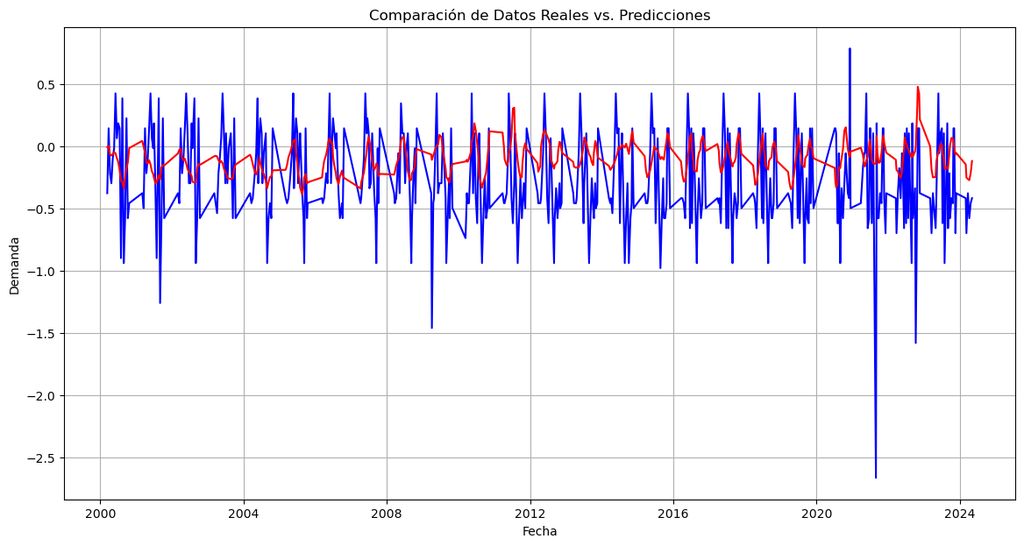

```python
winners = pd.read_csv('DCD-Modulo-6/winners.csv')

#Las varibles de interes son Laps, Time seconds, Average Lap Time, Grand Prix y Year, Date se usará como index
# Ya que Date y Time son object, las convetiré a Dtype numérico

# Para Date
winners['Date'] = pd.to_datetime(winners['Date']) #Convertir a datatime

winners['Year'] = winners['Date'].dt.year #Extraer el año
winners['Month'] = winners['Date'].dt.month #Extraer el mes
winners['Day'] = winners['Date'].dt.day #Extraer el día

#Para Time
winners['Time'] = winners['Time'].astype(str) #Convertir a cadena
winners['Time'] = pd.to_timedelta(winners['Time'], errors='coerce') #Convertir a timedelta
winners['Time_seconds'] = winners['Time'].dt.total_seconds() #Convertir el total de seg a numérico

#Otra variante relevante que no aparece en el dataset es el tiempo por vuelta, se agregará como variable adicional
winners['Average_Lap_Time'] = winners['Time_seconds'] / winners['Laps']

#También es relavante el GP, ya que influye en el Lap time
 # Para usarlo como variable ursaré Embedding
label_encoder = LabelEncoder()
winners['Grand Prix_encoded'] = label_encoder.fit_transform(winners['Grand Prix'])

winners.to_csv('DCD-Modulo-6/winners_modified.csv', index=False)

#Cargar los datos de entrenamiento
train_data = pd.read_csv('DCD-Modulo-6/winners_modified.csv', index_col='Date', parse_dates=True)

#Debido a que los datos de cada uno de los GP son específicos, para entrenar y validar el modelo dividiré mi base en 2
train_data_train = train_data[train_data['Year'] < 2000]  # Datos hasta 2000 para entrenamiento
train_data_val = train_data[train_data['Year'] >= 2000]  # Datos de 2000 para validación

 #Normalizaré las variables a usar, esto mejorará el rendimiento y estabilidad de el modelo
   #Para entrenaminento
scaler = StandardScaler()
train_data_train[['Laps', 'Time_seconds', 'Average_Lap_Time', 'Year']] = scaler.fit_transform(train_data_train[['Laps', 'Time_seconds', 'Average_Lap_Time', 'Year']])
   #Para validación
train_data_val[['Laps', 'Time_seconds', 'Average_Lap_Time', 'Year']] = scaler.transform(
    train_data_val[['Laps', 'Time_seconds', 'Average_Lap_Time', 'Year']]
)

# Crear las entradas para el modelo
input_grand_prix = Input(shape=(1,), dtype='int32', name='Grand_Prix_Input')  # Para Grand Prix
input_laps = Input(shape=(1,), dtype='float32', name='Laps_Input')  # Para Laps
input_time_seconds = Input(shape=(1,), dtype='float32', name='Time_Seconds_Input')  # Para Time_seconds
input_average_lap_time = Input(shape=(1,), dtype='float32', name='Average_Lap_Time_Input')  # Para Average_Lap_Time
input_year = Input(shape=(1,), dtype='float32', name='Year_Input')  # Para Year

# Capa de Embeddings para 'Grand Prix'
embedding_dim = 8  # Tamaño del espacio de embeddings
max_grand_prix = len(label_encoder.classes_)  # Número total de categorías únicas de 'Grand Prix'
embedding_layer = Embedding(input_dim=max_grand_prix, output_dim=embedding_dim, input_length=1)(input_grand_prix)

# Usar Flatten para aplanar la salida de la capa de embeddings
embedding_layer = Flatten()(embedding_layer)

# Concatenar la capa de embeddings con las otras variables
concatenated = Concatenate()([embedding_layer, input_laps, input_time_seconds, input_average_lap_time, input_year])

# Asegúrate de que la entrada a LSTM tenga 3 dimensiones
reshaped = Reshape((1, concatenated.shape[1]))(concatenated)

# LSTM y capa densa
lstm_layer = LSTM(64)(reshaped)
output = Dense(1, activation='linear')(lstm_layer)

# Crear el modelo
model = Model(inputs=[input_grand_prix, input_laps, input_time_seconds, input_average_lap_time, input_year], outputs=output)

# Compilar el modelo
model.compile(optimizer=Adam(), loss='mse')

# Resumen del modelo
model.summary()

train_data_train_or = train_data_train[['Laps', 'Time_seconds', 'Average_Lap_Time', 'Grand Prix_encoded', 'Year']]

#Limpieza de datos
train_data_train_or.replace(['---', '---', 'NaN', '', ''], np.nan, inplace=True)
imputer = SimpleImputer(strategy = 'mean')
train_data_train_or = pd.DataFrame(imputer.fit_transform(train_data_train_or), columns = train_data_train_or.columns, index=train_data_train_or.index)

#Escalado de datos
scaler = MinMaxScaler(feature_range=(0,1)) #Transforma los datos en 0 y 1
train_scaled_train = scaler.fit_transform(train_data_train_or)

#Crear secuencias temporales de datos para el entrenamiento
def create_dataset(dataset, look_back=60):
  X, Y = [], []
  for i in range(len(dataset) - look_back):
    a = dataset[i:(i+look_back), :]
    X.append(a)
    Y.append(dataset[i+look_back, 0])
  return np.array(X), np.array(Y)

X_train, y_train = create_dataset(train_scaled_train, 60)

#Modelo LSMT
model = Sequential([
    LSTM(100, input_shape=(X_train.shape[1], X_train.shape[2]), return_sequences=True), #return_sequences=True Devuelve salidas para cada paso (necesario para apilar LSTM)
    Dropout(0.2), #Evita el sobreajuste, apaga aleatoriamente el 20% de las neuronas durante el entrenamiento
    LSTM(100, return_sequences=False), #return sequences=False, nos da la salida final y no toda la sequencia
    Dense(1) #capa final densa
])
model.compile(optimizer=Adam(learning_rate=0.01), loss='mean_squared_error')

#Entrenar el modelo
model.fit(X_train, y_train, epochs=50, batch_size=32, verbose=1)

#Prepararlos datos reales del 2000 para comparación
train_data_val_or = train_data_val[['Laps', 'Time_seconds', 'Average_Lap_Time', 'Grand Prix_encoded', 'Year']]
train_data_val_or.replace(['---', '---', 'NaN', '', ''], np.nan, inplace=True)
train_data_val_or = pd.DataFrame(imputer.transform(train_data_val_or), columns=train_data_val_or.columns, index=train_data_val_or.index)
train_scaled_val_or = scaler.transform(train_data_val_or)

#Crear datos de entrada para predicción
X_real, _ = create_dataset(np.vstack([train_scaled_train[-60:], train_scaled_val_or]), 60)

#Predicciones
predictions_scaled = model.predict(X_real)
predictions_scaled = predictions_scaled.reshape(-1, 1) # Aseguranos de que las predicciones tengan 2 dimensiones
predictions_with_zeros = np.concatenate([predictions_scaled, np.zeros((predictions_scaled.shape[0], 4))], axis=1) #Crea una matriz de 0's del tamaño del dataset original
predictions = scaler.inverse_transform(predictions_with_zeros) #Aplicando la inversa del escalado
predictions = predictions[:, 0] #Extrae la columna de predicciones

#Datos reales para comparar
real_demand = scaler.inverse_transform(train_scaled_val_or)[:, 0]

#Graficar
plt.figure(figsize=(14, 7))
plt.plot(train_data_val_or.index, real_demand, label='Datos Reales 2024', color='blue')
plt.plot(train_data_val_or.index[:len(predictions)], predictions, label='Predicciones 2024', color='red')
plt.title('Comparación de Datos Reales vs. Predicciones')
plt.xlabel('Fecha')
plt.ylabel('Demanda')
plt.grid(True)
plt.show()
```

Para hacer que la curva de predicción se ajuste mejor a la de datos reales haré modificaciones:

```python
winners['Grand Prix'].unique()
```

```
array(['Great Britain', 'Monaco', 'Indianapolis 500', 'Switzerland',
       'Belgium', 'France', 'Italy', 'Germany', 'Spain', 'Netherlands',
       'Argentina', 'Pescara', 'Portugal', 'Morocco', 'United States',
       'South Africa', 'Mexico', 'Austria', 'Canada', 'Brazil', 'Sweden',
       'USA West', 'USA East', 'Japan', 'San Marino', "Caesar's Palace",
       'Detroit', 'Europe', 'Dallas', 'Australia', 'Hungary', 'Pacific',
       'Luxembourg', 'Malaysia', 'Bahrain', 'China', 'Turkey',
       'Singapore', 'Abu Dhabi', 'South Korea', 'India', 'Russia',
       'Azerbaijan', 'Styria', '70th Anniversary', 'Tuscany', 'Eifel',
       'Emilia Romagna', 'Sakhir', 'Qatar', 'Saudi Arabia', 'Miami',
       'Las Vegas'], dtype=object)
```

```
19/19 ━━━━━━━━━━━━━━━━━━━━ 5s 59ms/step - loss: 1.0966
19/19 ━━━━━━━━━━━━━━━━━━━━ 1s 60ms/step - loss: 0.0161
19/19 ━━━━━━━━━━━━━━━━━━━━ 1s 64ms/step - loss: 0.0125
19/19 ━━━━━━━━━━━━━━━━━━━━ 1s 64ms/step - loss: 0.0117
19/19 ━━━━━━━━━━━━━━━━━━━━ 1s 60ms/step - loss: 0.0108
19/19 ━━━━━━━━━━━━━━━━━━━━ 1s 62ms/step - loss: 0.0123
19/19 ━━━━━━━━━━━━━━━━━━━━ 1s 72ms/step - loss: 0.0096
19/19 ━━━━━━━━━━━━━━━━━━━━ 1s 68ms/step - loss: 0.0112
19/19 ━━━━━━━━━━━━━━━━━━━━ 1s 63ms/step - loss: 0.0112
19/19 ━━━━━━━━━━━━━━━━━━━━ 1s 59ms/step - loss: 0.0104
19/19 ━━━━━━━━━━━━━━━━━━━━ 1s 62ms/step - loss: 0.0100
19/19 ━━━━━━━━━━━━━━━━━━━━ 1s 58ms/step - loss: 0.0099
19/19 ━━━━━━━━━━━━━━━━━━━━ 1s 61ms/step - loss: 0.0096
19/19 ━━━━━━━━━━━━━━━━━━━━ 1s 68ms/step - loss: 0.0107
19/19 ━━━━━━━━━━━━━━━━━━━━ 1s 62ms/step - loss: 0.0113
19/19 ━━━━━━━━━━━━━━━━━━━━ 1s 59ms/step - loss: 0.0112
19/19 ━━━━━━━━━━━━━━━━━━━━ 1s 59ms/step - loss: 0.0105
19/19 ━━━━━━━━━━━━━━━━━━━━ 1s 65ms/step - loss: 0.0128
19/19 ━━━━━━━━━━━━━━━━━━━━ 1s 60ms/step - loss: 0.0096
19/19 ━━━━━━━━━━━━━━━━━━━━ 1s 65ms/step - loss: 0.0101
19/19 ━━━━━━━━━━━━━━━━━━━━ 1s 59ms/step - loss: 0.0106
19/19 ━━━━━━━━━━━━━━━━━━━━ 1s 60ms/step - loss: 0.0098
19/19 ━━━━━━━━━━━━━━━━━━━━ 1s 60ms/step - loss: 0.0114
19/19 ━━━━━━━━━━━━━━━━━━━━ 1s 58ms/step - loss: 0.0086
19/19 ━━━━━━━━━━━━━━━━━━━━ 1s 61ms/step - loss: 0.0108
19/19 ━━━━━━━━━━━━━━━━━━━━ 1s 62ms/step - loss: 0.0100
19/19 ━━━━━━━━━━━━━━━━━━━━ 1s 63ms/step - loss: 0.0105
19/19 ━━━━━━━━━━━━━━━━━━━━ 1s 61ms/step - loss: 0.0087
19/19 ━━━━━━━━━━━━━━━━━━━━ 1s 59ms/step - loss: 0.0099
19/19 ━━━━━━━━━━━━━━━━━━━━ 1s 58ms/step - loss: 0.0079
19/19 ━━━━━━━━━━━━━━━━━━━━ 1s 59ms/step - loss: 0.0080
19/19 ━━━━━━━━━━━━━━━━━━━━ 1s 61ms/step - loss: 0.0089
19/19 ━━━━━━━━━━━━━━━━━━━━ 1s 61ms/step - loss: 0.0097
19/19 ━━━━━━━━━━━━━━━━━━━━ 1s 65ms/step - loss: 0.0099
19/19 ━━━━━━━━━━━━━━━━━━━━ 1s 60ms/step - loss: 0.0116
19/19 ━━━━━━━━━━━━━━━━━━━━ 1s 64ms/step - loss: 0.0092
19/19 ━━━━━━━━━━━━━━━━━━━━ 1s 60ms/step - loss: 0.0093
19/19 ━━━━━━━━━━━━━━━━━━━━ 1s 59ms/step - loss: 0.0082
19/19 ━━━━━━━━━━━━━━━━━━━━ 1s 64ms/step - loss: 0.0095
19/19 ━━━━━━━━━━━━━━━━━━━━ 1s 65ms/step - loss: 0.0096
19/19 ━━━━━━━━━━━━━━━━━━━━ 1s 59ms/step - loss: 0.0108
19/19 ━━━━━━━━━━━━━━━━━━━━ 1s 61ms/step - loss: 0.0105
19/19 ━━━━━━━━━━━━━━━━━━━━ 1s 59ms/step - loss: 0.0077
19/19 ━━━━━━━━━━━━━━━━━━━━ 1s 59ms/step - loss: 0.0090
19/19 ━━━━━━━━━━━━━━━━━━━━ 1s 63ms/step - loss: 0.0113
19/19 ━━━━━━━━━━━━━━━━━━━━ 1s 60ms/step - loss: 0.0106
19/19 ━━━━━━━━━━━━━━━━━━━━ 1s 65ms/step - loss: 0.0090
19/19 ━━━━━━━━━━━━━━━━━━━━ 1s 64ms/step - loss: 0.0089
19/19 ━━━━━━━━━━━━━━━━━━━━ 1s 66ms/step - loss: 0.0111
19/19 ━━━━━━━━━━━━━━━━━━━━ 1s 69ms/step - loss: 0.0098
15/15 ━━━━━━━━━━━━━━━━━━━━ 1s 49ms/step
```

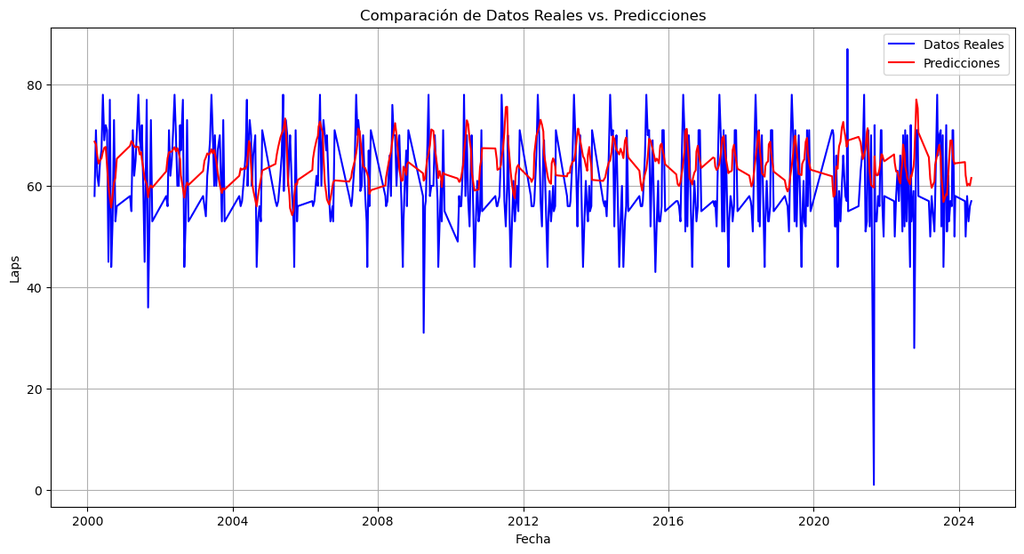

```python
winners = pd.read_csv('DCD-Modulo-6/winners.csv')

#Las varibles de interes son Laps, Time seconds, Average Lap Time, Grand Prix y Year, Date se usará como index
# Ya que Date y Time son object, las convetiré a Dtype numérico

winners['Date'] = pd.to_datetime(winners['Date'])
winners['Year'] = winners['Date'].dt.year
winners['Month'] = winners['Date'].dt.month
winners['Day'] = winners['Date'].dt.day

winners['Time'] = pd.to_timedelta(winners['Time'], errors='coerce')
winners['Time_seconds'] = winners['Time'].dt.total_seconds()
winners['Average_Lap_Time'] = winners['Time_seconds'] / winners['Laps']

# Agrupo los circuitos de cada GP por tipo
urban_tracks = [
    'Monaco', 'Singapore', 'Baku', 'Las Vegas', 'Miami',
    'Detroit', 'Dallas', 'Europe'
]

semiurban_tracks = [
    'Melbourne', 'Montreal', 'Jeddah', 'Sochi (Russia)',
    'Azerbaijan', 'Saudi Arabia', 'Miami'
]

special_tracks = [
    'Indianapolis 500', 'Caesar\'s Palace', 'Pescara',
    'Morocco', 'South Africa', 'Tuscany', '70th Anniversary',
    'Eifel', 'Sakhir', 'Styria', 'Emilia Romagna'
]

def map_circuit_type(grand_prix):
    if grand_prix in urban_tracks:
        return 0  # Urbano
    elif grand_prix in semiurban_tracks:
        return 1  # Semiurbano
    elif grand_prix in special_tracks:
        return 3  # Especial
    else:
        return 2  # Permanente

def map_circuit_label(circuit_type):
    labels = {
        0: 'Urbano',
        1: 'Semiurbano',
        2: 'Permanente',
        3: 'Especial'
    }
    return labels[circuit_type]

# Aplíco mapeos
winners['Circuit_Type'] = winners['Grand Prix'].apply(map_circuit_type)
winners['Circuit_Label'] = winners['Circuit_Type'].apply(map_circuit_label)

# Codifico Grand Prix original
label_encoder = LabelEncoder()
winners['Grand Prix_encoded'] = label_encoder.fit_transform(winners['Grand Prix'])

# Transformo Year en ciclo estacional (coseno y seno)
winners['Year_sin'] = np.sin(2 * np.pi * winners['Year'] / winners['Year'].max())
winners['Year_cos'] = np.cos(2 * np.pi * winners['Year'] / winners['Year'].max())

# Guardo datos procesados
winners.to_csv('DCD-Modulo-6/winners_modified.csv', index=False)

# Cargo los datos de entrenamiento
train_data = pd.read_csv('DCD-Modulo-6/winners_modified.csv', index_col='Date', parse_dates=True)

# #Debido a que los datos de cada uno de los GP son específicos, para entrenar y validar el modelo dividiré mi base en 2
train_data_train = train_data[train_data['Year'] < 2000]
train_data_val = train_data[train_data['Year'] >= 2000]

# Variables que usaré
features = ['Laps', 'Time_seconds', 'Average_Lap_Time', 'Grand Prix_encoded', 'Circuit_Type', 'Year_sin', 'Year_cos']

# Limpieza de datos
imputer = SimpleImputer(strategy='mean')
train_data_train[features] = imputer.fit_transform(train_data_train[features])
train_data_val[features] = imputer.transform(train_data_val[features])

# Normalización y escalado de datos
scaler = MinMaxScaler()
train_scaled_train = scaler.fit_transform(train_data_train[features])
train_scaled_val = scaler.transform(train_data_val[features])

# Crear secuencias temporales de datos para el entrenamiento
def create_dataset(dataset, look_back=60):
    X, Y = [], []
    for i in range(len(dataset) - look_back):
        a = dataset[i:(i+look_back), :]
        X.append(a)
        Y.append(dataset[i+look_back, 0])  # target = Laps
    return np.array(X), np.array(Y)

X_train, y_train = create_dataset(train_scaled_train, 60)

# Modelo LSTM
model = Sequential([
    LSTM(100, input_shape=(X_train.shape[1], X_train.shape[2]), return_sequences=True),
    Dropout(0.2),
    LSTM(100, return_sequences=False),
    Dense(1)
])
model.compile(optimizer=Adam(learning_rate=0.01), loss='mean_squared_error')

# Entrenar el modelo
model.fit(X_train, y_train, epochs=50, batch_size=32, verbose=1)

# Predicciones
X_real, _ = create_dataset(np.vstack([train_scaled_train[-60:], train_scaled_val]), 60)
predictions_scaled = model.predict(X_real)
predictions_scaled = predictions_scaled.reshape(-1, 1)

# Inversa del escalado
zeros_for_rest = np.zeros((predictions_scaled.shape[0], len(features) - 1))
predictions_with_zeros = np.concatenate([predictions_scaled, zeros_for_rest], axis=1)
predictions = scaler.inverse_transform(predictions_with_zeros)[:, 0]

# Datos reales para comparar
real_demand = scaler.inverse_transform(train_scaled_val)[:, 0]

# Graficar
plt.figure(figsize=(14, 7))
plt.plot(train_data_val.index, real_demand, label='Datos Reales', color='blue')
plt.plot(train_data_val.index[:len(predictions)], predictions, label='Predicciones', color='red')
plt.title('Comparación de Datos Reales vs. Predicciones')
plt.xlabel('Fecha')
plt.ylabel('Laps')
plt.legend()
plt.grid(True)
plt.show()
```

```python
import plotly.graph_objects as go
import pandas as pd
from sklearn.metrics import r2_score

# Asegurarse de que tanto 'real_demand' como 'predictions' tienen el mismo índice de tiempo
# Usamos train_data_val.index para asegurarnos de que los índices sean correctos
real_demand = pd.Series(real_demand[:len(predictions)], index=train_data_val.index[:len(predictions)])
predictions_series = pd.Series(predictions, index=train_data_val.index[:len(predictions)])

# Crear una lista para almacenar los R-squared de cada año
r_squared_yearly = []

# Agrupar los datos por año y calcular el R-squared para cada año
for year, group in real_demand.groupby(real_demand.index.year):
    # Extraer las predicciones correspondientes para ese año
    pred_for_year = predictions_series[group.index]

    # Calcular el R-squared
    r_squared = r2_score(group, pred_for_year)

    # Almacenar el resultado
    r_squared_yearly.append((year, r_squared))
    print(f'R-squared para el año {year}: {r_squared:.4f}')

# Crear la figura usando Plotly para una mejor interactividad y presentación
fig = go.Figure()

# Añadir los datos reales a la gráfica
fig.add_trace(go.Scatter(x=train_data_val.index, y=real_demand, mode='lines', name='Datos Reales', line=dict(color='blue')))

# Añadir las predicciones a la gráfica
fig.add_trace(go.Scatter(x=train_data_val.index[:len(predictions)], y=predictions, mode='lines', name='Predicciones', line=dict(color='red')))

# Configuración adicional del gráfico
fig.update_layout(
    title='Comparación de Predicciones vs Datos Reales por Año',
    xaxis_title='Fecha',
    yaxis_title='Número de Vueltas (Laps)',
    legend_title='Leyenda'
)

# Mostrar la gráfica
fig.show()

# Imprimir los R-squared anuales
for year, r_squared in r_squared_yearly:
    print(f"R-squared para el año {year}: {r_squared:.4f}")
```

```
R-squared para el año 2000: 0.1854
R-squared para el año 2001: 0.1588
R-squared para el año 2002: 0.1630
R-squared para el año 2003: 0.0509
R-squared para el año 2004: 0.2821
R-squared para el año 2005: 0.0328
R-squared para el año 2006: -0.1614
R-squared para el año 2007: 0.1485
R-squared para el año 2008: 0.1654
R-squared para el año 2009: -0.1722
R-squared para el año 2010: -0.2016
R-squared para el año 2011: -0.7040
R-squared para el año 2012: -0.3829
R-squared para el año 2013: -0.6705
R-squared para el año 2014: -0.4711
R-squared para el año 2015: -0.2673
R-squared para el año 2016: -0.1801
R-squared para el año 2017: -0.3625
R-squared para el año 2018: -0.2584
R-squared para el año 2019: -0.2397
R-squared para el año 2020: -0.4575
R-squared para el año 2021: -0.0571
R-squared para el año 2022: -0.3923
R-squared para el año 2023: -0.0224
R-squared para el año 2024: -5.4702
```

[interactive chart not shown]

```
R-squared para el año 2000: 0.1854
R-squared para el año 2001: 0.1588
R-squared para el año 2002: 0.1630
R-squared para el año 2003: 0.0509
R-squared para el año 2004: 0.2821
R-squared para el año 2005: 0.0328
R-squared para el año 2006: -0.1614
R-squared para el año 2007: 0.1485
R-squared para el año 2008: 0.1654
R-squared para el año 2009: -0.1722
R-squared para el año 2010: -0.2016
R-squared para el año 2011: -0.7040
R-squared para el año 2012: -0.3829
R-squared para el año 2013: -0.6705
R-squared para el año 2014: -0.4711
R-squared para el año 2015: -0.2673
R-squared para el año 2016: -0.1801
R-squared para el año 2017: -0.3625
R-squared para el año 2018: -0.2584
R-squared para el año 2019: -0.2397
R-squared para el año 2020: -0.4575
R-squared para el año 2021: -0.0571
R-squared para el año 2022: -0.3923
R-squared para el año 2023: -0.0224
R-squared para el año 2024: -5.4702
```

## Conclusión:

El desempeño del modelo no es el mejor, ya que los R-squared son bajos o negativos en casi todos los años.

Esto se debe a la baja cantidad de datos en comparación con otros datasets. Además de que los datos de F1 han cambiado con el tiempo (por ejemplo, mejoras en los autos, cambios en los circuitos, etc), patrones que no se están capturando debido a que se necesitarían muchas más variables para ello.

El motivo de la elección de este dataset fue mi grán pasion por el deporte motor y el interes en enfocar mi proyecto en entender más su histora y predicción. Además de enfocar mis aprendizajes en una tema relevante y de uso para mi.